# Analiza ladijskih nesreč

Bor Bregant

24. oktober 2021

# Uvod

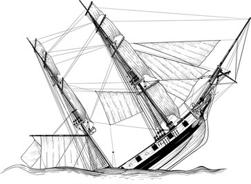

V projektu je analiza nesreč z rekreativnimi plovili. Deskriptivno so prikazane okoliščine nesreč, analitično pa je vključena še linearna regresija števila smrtnih nesreč v oziru na število registriranih plovil in povprečnega prihodka državljana ZDA. V shiny je še spletna aplikacija, ki prikazuje število nesreč v oziru na okoliščine nesreče.

# Spletna povezava do vira tabel za nesreče [pdf], spletna povezava do vira povrečnega prihodka in grob opis podatkov izvlečenih tabel:

[2020 Recreational boating statistics](https://uscgboating.org/library/accident-statistics/Recreational-Boating-Statistics-2020.pdf)

[Pihodek v ZDA v letu 2020](https://fred.stlouisfed.org/series/A792RC0A052NBEA)

1. TABELA: (Nesreče v posameznih mesecih)
   1. Mesec (faktor)
   2. Smrtne nesreče (niz)
   3. Nesmrtne nesreče (niz)
   4. Vse nesreče (niz)
   5. Procent smrtnih nesreč (niz)
   6. Število smrti (stevilo)
2. TABELA: (Nesreče v posameznih letij)
   1. Leto (stevilo)
   2. Smrtne nesreče (stevilo)
   3. Nesmrtne nesreče (stevilo)
   4. Vse nesreče (stevilo)
3. TABELA: (Nesreče v posamezni zvezni državi)
   1. Zvezna država (niz)
   2. Vse nesreče (stevilo)
   3. Smrtne nesreče (stevilo)
   4. Vse nesreče (stevilo)
   5. Oškodovani (stevilo)
   6. Število smrti (stevilo)
   7. Število ponesrečencev (stevilo)
   8. Škoda v USD (stevilo)
4. TABELA: (Število registriranih plovil)
   1. Leto (stevilo)
   2. Število smrti (stevilo)
   3. Število registriranih plovil (stevilo)
   4. Delež smrtnih izidov (stevilo)
   5. Število smrti v plovilih z motorjem (stevilo)
   6. Število registriranih motornih plovil (stevilo)
   7. Delež smrnih izidov z motornim plovilom (stevilo)
5. TABELA: (Prihodek državljana ZDA)
   1. Leto (stevilo)
   2. Povprečni prihodek (stevilo)
6. TABELA: (Vzrok nesreč)
   1. Vzrok (faktor)
   2. Število nesreč (stevilo)
   3. Število smrti (stevilo)
   4. Število poškodb (stevilo)
   5. Tip nesreče (niz)

# Vizualizacija podatkov

Na zemljevidu ZDA je prikazano število smrtnih nesreč glede na posamezno zvezno državo.

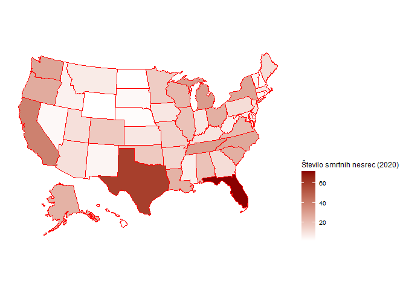

Graf števila smrti v posameznem mesecu (v letu 2020)

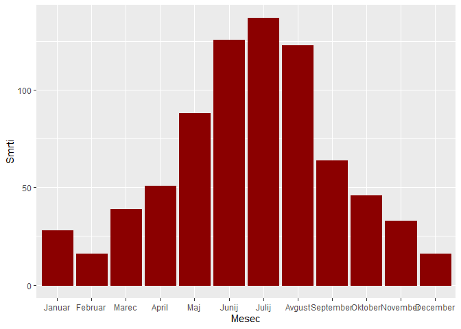

Graf števila smrti v posameznem letu

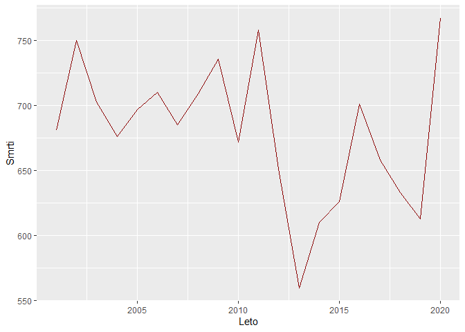

# Regresijska analiza

Grafa števila registriranih plovil in prihodka na prebivalca, ki bosta naši pojasnjevalni količini v regresijskem modelu.

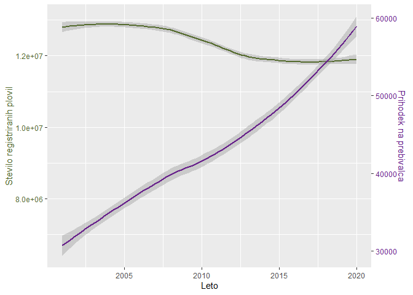

Pod izhodom si oglejmo še diagnostiko predpostavk linearne regresije. $R^2$ je zelo majhen, kar ni dober znak. Rdeča črta ostankov proti fittanim vrednostim je sicer dobra (ravna okoli 0), a nas motijo same vrednosti (ta preveri samo linearnost podatkov). Drugi in tretji graf sta (morda presentiljo) zadovoljiva.

```
##
## Call:
## lm(formula = Smrti ~ Prihodek + Registrirane, data = registracije)
##
## Residuals:
##     Min      1Q  Median      3Q     Max
## -86.357 -20.868  -8.334  15.955 100.969
##
## Coefficients:
##                Estimate Std. Error t value Pr(>|t|)
## (Intercept)  -9.249e+02  8.168e+02  -1.132    0.273
## Prihodek      3.802e-03  3.062e-03   1.241    0.231
## Registrirane  1.166e-04  5.633e-05   2.070    0.054 .
## ---
## Signif. codes:  0 '***' 0.001 '**' 0.01 '*' 0.05 '.' 0.1 ' ' 1
##
## Residual standard error: 48.68 on 17 degrees of freedom
## Multiple R-squared:  0.2679, Adjusted R-squared:  0.1817
## F-statistic:  3.11 on 2 and 17 DF,  p-value: 0.07065
```

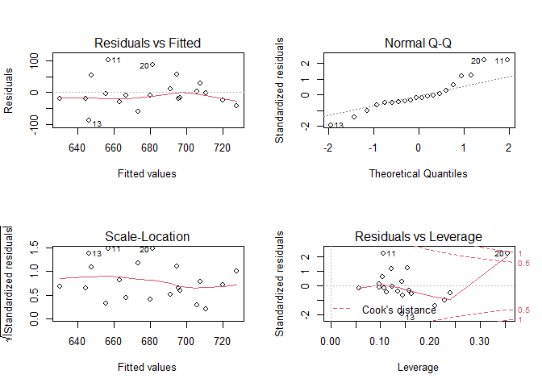